# cs7324 Lab 4 - The Multi-Layer Perceptron

#### Chip Henderson - 48996654

## 1. Load, Split, and Balance the Dataset

```python
import pandas as pd

census_df = pd.read_csv('acs2017_census_tract_data.csv', sep=',')

census_df.head()
```

|  | TractId | State | County | TotalPop | Men | Women | Hispanic | White | Black | Native | ... | Walk | OtherTransp | WorkAtHome | MeanCommute | Employed | PrivateWork | PublicWork | SelfEmployed | FamilyWork | Unemployment |
| --- | --- | --- | --- | --- | --- | --- | --- | --- | --- | --- | --- | --- | --- | --- | --- | --- | --- | --- | --- | --- | --- |
| 0 | 1001020100 | Alabama | Autauga County | 1845 | 899 | 946 | 2.4 | 86.3 | 5.2 | 0.0 | ... | 0.5 | 0.0 | 2.1 | 24.5 | 881 | 74.2 | 21.2 | 4.5 | 0.0 | 4.6 |
| 1 | 1001020200 | Alabama | Autauga County | 2172 | 1167 | 1005 | 1.1 | 41.6 | 54.5 | 0.0 | ... | 0.0 | 0.5 | 0.0 | 22.2 | 852 | 75.9 | 15.0 | 9.0 | 0.0 | 3.4 |
| 2 | 1001020300 | Alabama | Autauga County | 3385 | 1533 | 1852 | 8.0 | 61.4 | 26.5 | 0.6 | ... | 1.0 | 0.8 | 1.5 | 23.1 | 1482 | 73.3 | 21.1 | 4.8 | 0.7 | 4.7 |
| 3 | 1001020400 | Alabama | Autauga County | 4267 | 2001 | 2266 | 9.6 | 80.3 | 7.1 | 0.5 | ... | 1.5 | 2.9 | 2.1 | 25.9 | 1849 | 75.8 | 19.7 | 4.5 | 0.0 | 6.1 |
| 4 | 1001020500 | Alabama | Autauga County | 9965 | 5054 | 4911 | 0.9 | 77.5 | 16.4 | 0.0 | ... | 0.8 | 0.3 | 0.7 | 21.0 | 4787 | 71.4 | 24.1 | 4.5 | 0.0 | 2.3 |

5 rows × 37 columns

```python
census_df.info()
```

```
<class 'pandas.core.frame.DataFrame'>
RangeIndex: 74001 entries, 0 to 74000
Data columns (total 37 columns):
 #   Column            Non-Null Count  Dtype
---  ------            --------------  -----
 0   TractId           74001 non-null  int64
 1   State             74001 non-null  object
 2   County            74001 non-null  object
 3   TotalPop          74001 non-null  int64
 4   Men               74001 non-null  int64
 5   Women             74001 non-null  int64
 6   Hispanic          73305 non-null  float64
 7   White             73305 non-null  float64
 8   Black             73305 non-null  float64
 9   Native            73305 non-null  float64
```

[output cut: 29 more lines]

The object data types will need to be recoded so they can be fed into the model. First I'll check to see if there are any missing values I need to deal with.

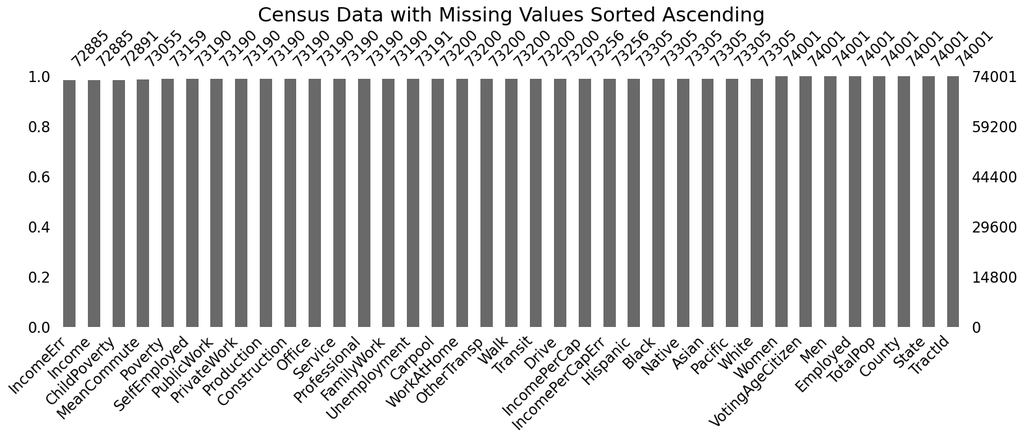

```python
# Referencing code from lecture and in-class examples and lab 1
import matplotlib
import matplotlib.pyplot as plt
import warnings
warnings.simplefilter('ignore', DeprecationWarning)
%matplotlib inline

import missingno as mn
# As a departure from lecture code I'm using a bar chart,
# Matrix version gave me errors regarding 'grid_b' which I wasn't able to resolve
mn.bar(census_df, sort="ascending", figsize=(18,5))
plt.title("Census Data with Missing Values Sorted Ascending",fontsize=22)
```

Based on the bar chart above I can see that there are several categories with missing data. To handle all of this at once I'll use the dropna() method of the dataframe.

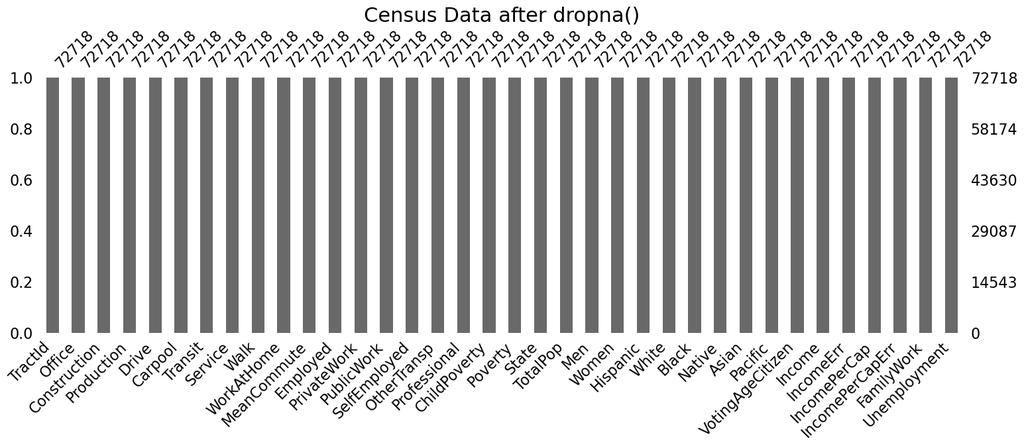

```python
census_df = census_df.dropna()
census_df = census_df.drop('County', axis=1) # added later

mn.bar(census_df, sort="ascending", figsize=(18,5))
plt.title("Census Data after dropna()",fontsize=22)
```

Now all the features have the same number of values. Next, I need to convert the string data to integers. To do that I'll enumerate each unique value and map the values to their corresponding integer values.

Originally I kept county data in my dataframe and subsequently went back to remove it. Part of the issue with keeping so much unique data is that when I tried to run without one-hot encoding the amount of memory required was over 25 GiB. Furthermore, since the focus the prediction task is based on TractId which appears to be held at the same or lower level than county, having county was an unnecesary complicating factor of the dataset.

```python
census_df['State'] = census_df['State'].str.lower()
unique_state_vals = list(enumerate(census_df.State.unique()))
unique_state_vals = [t[::-1] for t in unique_state_vals] # reverse the elements
state_dict = dict(unique_state_vals) # create dictionary for mapping
census_df['State'] = census_df['State'].map(state_dict)

# census_df['County'] = census_df['County'].str.lower()
# unique_county_vals = list(enumerate(census_df.County.unique()))
# unique_county_vals = [t[::-1] for t in unique_county_vals]
# county_dict = dict(unique_county_vals)
# census_df['County'] = census_df['County'].map(county_dict)

census_df.info()
```

```
<class 'pandas.core.frame.DataFrame'>
Index: 72718 entries, 0 to 74000
Data columns (total 36 columns):
 #   Column            Non-Null Count  Dtype
---  ------            --------------  -----
 0   TractId           72718 non-null  int64
 1   State             72718 non-null  int64
 2   TotalPop          72718 non-null  int64
 3   Men               72718 non-null  int64
 4   Women             72718 non-null  int64
 5   Hispanic          72718 non-null  float64
 6   White             72718 non-null  float64
 7   Black             72718 non-null  float64
 8   Native            72718 non-null  float64
 9   Asian             72718 non-null  float64
```

[output cut: 28 more lines]

Now all of my data is in some sort of number format and I can move on to balancing.

#### Balance the Dataset

First we'll look at the categories for ChildPoverty to determine how we might split the data by these values.

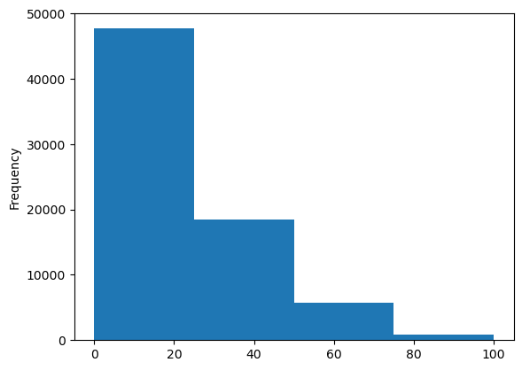

```python
census_df.ChildPoverty.plot.hist(bins=4)
```

```python
import numpy as np

census_df['ChildPoverty_range'] = pd.cut(census_df['ChildPoverty'],
                                 [-np.inf,24.0,49.0,74.0,np.inf], # Group from 0 to 25, 25 to 50, and 50 to 100
                                 labels=[0, 1, 2, 3])

census_df['ChildPoverty_range'] = census_df['ChildPoverty_range'].astype(int)
print(census_df.ChildPoverty_range.value_counts())
```

```
ChildPoverty_range
0    46642
1    19171
2     5965
3      940
Name: count, dtype: int64
```

To balance the dataset based on child poverty, I need to oversample by replicating instances where the child poverty rate is in the second, third, and fourth quartiles, as these are lower than the first quartile. This will allow my model sufficient information to train on.

```python
# Source: ChatGPT for methods to capture indexes of particular values
# Get booleans where child poverty rate range is 1, 2 or 3
cpr_2 = (census_df['ChildPoverty_range'] == 1) # using cpr as abbrv. child poverty rate
cpr_3 = (census_df['ChildPoverty_range'] == 2)
cpr_4 = (census_df['ChildPoverty_range'] == 3)

# Use the boolean values to get indexes of values for each quartile
idx_matching_2 = census_df[cpr_2].index
idx_matching_3 = census_df[cpr_3].index
idx_matching_4 = census_df[cpr_4].index
```

Duplicate data based on the above quantity of each category from above. I won't get carried away trying to make each category exactly equal. I know that category 2 should be duplicated about once, category 3 should be duplicated about 7 times, cateogry 4 should be duplicated about 44 times. This should give me a better representation of each value for the model to train on.

```python
# Start by creating new dataframes of the selected indices
census_df_cpr2 = census_df.loc[idx_matching_2]
census_df_cpr3 = census_df.loc[idx_matching_3]
census_df_cpr4 = census_df.loc[idx_matching_4]

# now append the datasets together the appropriate number of times
for x in range(1):
    census_df = pd.concat([census_df, census_df_cpr2], ignore_index=True)

for x in range(7):
    census_df = pd.concat([census_df, census_df_cpr3], ignore_index=True)

for x in range(44):
    census_df = pd.concat([census_df, census_df_cpr4], ignore_index=True)
```

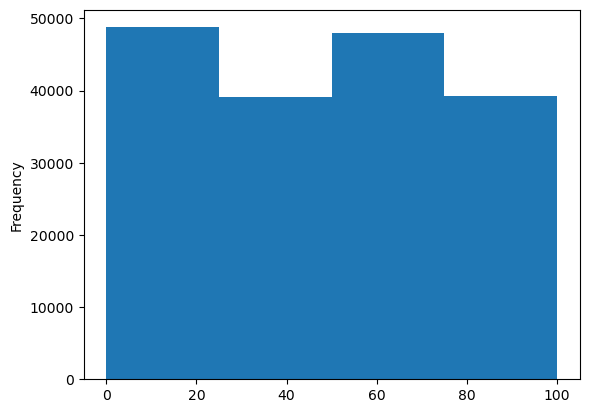

```python
# Check our balance of values again
census_df.ChildPoverty.plot.hist(bins=4)
```

```python
print(census_df.ChildPoverty_range.value_counts())
```

```
ChildPoverty_range
2    47720
0    46642
3    42300
1    38342
Name: count, dtype: int64
```

This is a better but not perfect distribution to move forward with. Now I should be ready to perform my test/train split:

```python
# Perform the test/train split of the data
from sklearn.model_selection import train_test_split
from sklearn.metrics import accuracy_score

# I'll clean up a few more columns to drop before setting X and y
census_df = census_df.drop(columns=['ChildPoverty'])

X = census_df.iloc[:,:census_df.shape[1]-1].values # select all columns except last
y = census_df.ChildPoverty_range.to_numpy() # last column are my targets

X_train, X_test, y_train, y_test = train_test_split(X, y, train_size = 0.8, test_size=0.2)
print(X_train.shape)
print(y_train.shape)
print(X_test.shape)
print(y_test.shape)
```

```
(140003, 35)
(140003,)
(35001, 35)
(35001,)
```

#### Should balancing the dataset be done for both the training and testing set?

Balancing the dataset should not need to be done specifically for the testing data. Once our model is trained, the individual values it is tested against shouldn't matter whether they are equally representative. To speak specifically to this situation, I am splitting the data for my testing and training after I have already made modifications to the basic data to balance. Therefore my testing data is balanced by default. Ideally we wouldn't want to bias our test data by modifying it.

## 2. Preprocessing and Initial Modeling

Here, I'm incorporating the TwoLayerPerceptronBase from the in class 08a notebook with:

- An updated _initalize_weights function to implement Glorot weights
- An updated _cost and _get_gradient function to use the cross entropy equation
- Also, this base uses Vectorized backpropogation

As an aside, I left momentum in here as it was not a requirement to remove it.

```python
# Source: Modified from in-class lecture

import numpy as np
from scipy.special import expit
import pandas as pd
import sys

# start with a simple base classifier, which can't be fit or predicted
# it only has internal classes to be used by classes that will subclass it
class TwoLayerPerceptronBase(object):
    def __init__(self, n_hidden=30,
                 C=0.0, epochs=500, eta=0.001, random_state=None):
        np.random.seed(random_state)
        self.n_hidden = n_hidden
        self.l2_C = C
        self.epochs = epochs
        self.eta = eta

    @staticmethod
    def _encode_labels(y):
        """Encode labels into one-hot representation"""
        onehot = pd.get_dummies(y).values.T

        return onehot


    def _initialize_weights(self): # implement glorot
        """Initialize weights Glorot and He normalization."""
        init_bound = 4*np.sqrt(6. / (self.n_hidden + self.n_features_))
        W1 = np.random.uniform(-init_bound, init_bound,(self.n_hidden, self.n_features_))

        # reduce the final layer magnitude in order to balance the size of the gradients
        # between
        init_bound = 4*np.sqrt(6 / (self.n_output_ + self.n_hidden))
        W2 = np.random.uniform(-init_bound, init_bound,(self.n_output_, self.n_hidden))

        # set these to zero to start so that
        # they do not immediately saturate the neurons
        b1 = np.zeros((self.n_hidden, 1))
        b2 = np.zeros((self.n_output_, 1))

        return W1, W2, b1, b2


    @staticmethod
    def _sigmoid(z):
        """Use scipy.special.expit to avoid overflow"""
        # 1.0 / (1.0 + np.exp(-z))
        return expit(z)


    @staticmethod
    def _L2_reg(lambda_, W1, W2):
        """Compute L2-regularization cost"""
        # only compute for non-bias terms
        return (lambda_/2.0) * np.sqrt(np.mean(W1[:, 1:] ** 2) + np.mean(W2[:, 1:] ** 2))


    def _cost(self,A3,Y_enc,W1,W2): # implement cross-entropy equation
        '''Get the objective function value'''
        cost = -np.mean(np.nan_to_num((Y_enc*np.log(A3+1e-7)+(1-Y_enc)*np.log(1-A3+1e-7))))
        L2_term = self._L2_reg(self.l2_C, W1, W2)
        return cost + L2_term


    def _feedforward(self, X, W1, W2, b1, b2):
        """Compute feedforward step
        -----------
        X : Input layer with original features.
        W1: Weight matrix for input layer -> hidden layer.
        W2: Weight matrix for hidden layer -> output layer.
        ----------
        a1-a3 : activations into layer (or output layer)
        z1-z2 : layer inputs

        """
        A1 = X.T
        Z1 = W1 @ A1 + b1
        A2 = self._sigmoid(Z1)
        Z2 = W2 @ A2 + b2
        A3 = self._sigmoid(Z2)
        return A1, Z1, A2, Z2, A3


    # Replaced get gradient function from lecture with cross-entropy version
    def _get_gradient(self, A1, A2, A3, Z1, Z2, Y_enc, W1, W2):
        """ Compute gradient step using backpropagation.
        """
        # vectorized backpropagation and V2 for cross-entropy
        V2 = (A3-Y_enc) # <- this is only line that changed
        V1 = A2*(1-A2)*(W2.T @ V2)

        gradW2 = V2 @ A2.T
        gradW1 = V1 @ A1.T

        gradb2 = np.sum(V2, axis=1).reshape((-1,1))
        gradb1 = np.sum(V1, axis=1).reshape((-1,1))

        # regularize weights that are not bias terms
        gradW1 += W1 * self.l2_C
        gradW2 += W2 * self.l2_C

        return gradW1, gradW2, gradb1, gradb2


    def predict(self, X):
        """Predict class labels"""
        _, _, _, _, A3 = self._feedforward(X, self.W1, self.W2, self.b1, self.b2)
        y_pred = np.argmax(A3, axis=0)
        return y_pred
```

Here, I'll use the TLPMiniBatch class which will reference my updated TwoLayerPercetpronBase. This is directly from lecture, 08a notebook, unaltered.

```python
# Source: Modified from in class lecture

from sklearn.metrics import accuracy_score

# just start with the vectorized version and minibatch
class TLPMiniBatch(TwoLayerPerceptronBase):
    def __init__(self, alpha=0.0, decrease_const=0.1,
                 decrease_iter = 10, shuffle=True,
                 minibatches=1, **kwds):
        # need to add to the original initializer
        self.alpha = alpha
        self.decrease_const = decrease_const
        self.decrease_iter = decrease_iter
        self.shuffle = shuffle
        self.minibatches = minibatches
        # but keep other keywords
        super().__init__(**kwds)


    def fit(self, X, y, print_progress=False, XY_test=None):
        """ Learn weights from training data. With mini-batch"""
        X_data, y_data = X.copy(), y.copy()
        Y_enc = self._encode_labels(y)

        # init weights and setup matrices
        self.n_features_ = X_data.shape[1]
        self.n_output_ = Y_enc.shape[0]
        self.W1, self.W2, self.b1, self.b2 = self._initialize_weights()

        # start momentum at zero for previous updates
        rho_W1_prev = np.zeros(self.W1.shape) # for momentum
        rho_W2_prev = np.zeros(self.W2.shape) # for momentum

        self.cost_ = []
        self.score_ = []
        # get starting acc
        self.score_.append(accuracy_score(y_data,self.predict(X_data)))
        # keep track of validation, if given
        if XY_test is not None:
            X_test = XY_test[0].copy()
            y_test = XY_test[1].copy()
            self.val_score_ = []
            self.val_score_.append(accuracy_score(y_test,self.predict(X_test)))
            self.val_cost_ = []

        for i in range(self.epochs):

            # adaptive learning rate
            # decrease at certain epochs
            eta = self.eta * self.decrease_const**(np.floor(i/self.decrease_iter))

            if print_progress>0 and (i+1)%print_progress==0:
                sys.stderr.write('\rEpoch: %d/%d' % (i+1, self.epochs))
                sys.stderr.flush()

            if self.shuffle:
                idx_shuffle = np.random.permutation(y_data.shape[0])
                X_data, Y_enc, y_data = X_data[idx_shuffle], Y_enc[:, idx_shuffle], y_data[idx_shuffle]

            mini = np.array_split(range(y_data.shape[0]), self.minibatches)
            mini_cost = []

            for idx in mini:

                # feedforward
                A1, Z1, A2, Z2, A3 = self._feedforward(X_data[idx],
                                                       self.W1,
                                                       self.W2,
                                                       self.b1,
                                                       self.b2
                                                      )

                cost = self._cost(A3,Y_enc[:, idx],self.W1,self.W2)
                mini_cost.append(cost) # this appends cost of mini-batch only

                # compute gradient via backpropagation
                gradW1, gradW2, gradb1, gradb2 = self._get_gradient(A1=A1, A2=A2, A3=A3, Z1=Z1, Z2=Z2,
                                                  Y_enc=Y_enc[:, idx],
                                                  W1=self.W1,W2=self.W2)

                # simple momentum calculations
                rho_W1, rho_W2 = eta * gradW1, eta * gradW2
                self.W1 -= (rho_W1 + (self.alpha * rho_W1_prev)) # update with momentum
                self.W2 -= (rho_W2 + (self.alpha * rho_W2_prev)) # update with momentum

                # no need for momentum in bias
                # these values need to change abruptly and
                # do not influence sensitivity backward
                self.b1 -= eta * gradb1
                self.b2 -= eta * gradb2

                # update previous parameters
                rho_W1_prev, rho_W2_prev = rho_W1, rho_W2

            self.cost_.append(np.mean(mini_cost))
            self.score_.append(accuracy_score(y_data,self.predict(X_data)))

            # update if a validation set was provided
            if XY_test is not None:
                yhat = self.predict(X_test)
                self.val_score_.append(accuracy_score(y_test,yhat))

        return self
```

Finally, I'll add in the plotting function from lecture as well

```python
# Source: Modified from in-class lecture, removed 'val_score'

from sklearn.metrics import accuracy_score
import matplotlib.pyplot as plt
%matplotlib inline

plt.style.use('ggplot')

def print_result(nn,X_train,y_train,X_test,y_test,title="",color="red"):

    print("=================")
    print(title,":")
    yhat = nn.predict(X_train)
    print('Resubstitution acc:',accuracy_score(y_train,yhat))

    yhat = nn.predict(X_test)
    print('Validation acc:',accuracy_score(y_test,yhat))

#     if hasattr(nn,'val_score_'):
#         plt.plot(range(len(nn.val_score_)), nn.val_score_, color=color,label=title)
#         plt.ylabel('Validation Accuracy')
#     else:
#         plt.plot(range(len(nn.score_)), nn.score_, color=color,label=title)
#         plt.ylabel('Resub Accuracy')

#     plt.xlabel('Epochs')
#     plt.tight_layout()
#     plt.legend(loc='best')
#     plt.grid(True)
```

### Two-Layer Perceptron - No data alteration

Now I will run a test using non-normalized data and without one-hot encoding to see the initial results.

```python
vals = { 'n_hidden':50, # originally 40
         'C':0.001, # originally 0.1
         'epochs':40, # originally 40
         'eta':0.0005, # originally 0.01
         'alpha':0.001,
         'decrease_const':0.1,
         'decrease_iter':15,
         'minibatches':50, # originally 1
         'shuffle':True,'random_state':1
       }

X_train_unalt, y_train_unalt, X_test_unalt, y_test_unalt = X_train, y_train, X_test, y_test

nn_unalt = TLPMiniBatch(**vals)

%time nn_unalt.fit(X_train_unalt, y_train_unalt, print_progress=1, XY_test=(X_test_unalt, y_test_unalt))
yhat_unalt = nn_unalt.predict(X_train_unalt)
```

```
Epoch: 40/40
```

```
CPU times: total: 2min 11s
Wall time: 43.7 s
```

### Two-Layer Perceptron - Normalized Data

Now I need to normalize my data and try another test.

```python
from sklearn.preprocessing import StandardScaler

scaler = StandardScaler()
X = StandardScaler().fit_transform(X)

X_train_norm, X_test_norm, y_train_norm, y_test_norm = train_test_split(X, y, train_size = 0.8, test_size=0.2)

nn_norm = TLPMiniBatch(**vals)

%time nn_norm.fit(X_train_norm, y_train_norm, print_progress=1, XY_test=(X_test_norm, y_test_norm))
yhat_norm = nn_norm.predict(X_train_norm)
```

```
Epoch: 40/40
```

```
CPU times: total: 57.8 s
Wall time: 18.8 s
```

### Two-Layer Perceptron - Normalized Data and One-Hot Encoding

We still need to one-hot encode the categorical data, so I'll do that next.

```python
tmp_df = pd.get_dummies(census_df.State,prefix='state')
census_df = pd.concat((census_df,tmp_df),axis=1)

# tmp_df = pd.get_dummies(census_df.County,prefix='county')
# census_df = pd.concat((census_df,tmp_df),axis=1)

census_df.info()
```

```
<class 'pandas.core.frame.DataFrame'>
RangeIndex: 175004 entries, 0 to 175003
Data columns (total 88 columns):
 #   Column              Non-Null Count   Dtype
---  ------              --------------   -----
 0   TractId             175004 non-null  int64
 1   State               175004 non-null  int64
 2   TotalPop            175004 non-null  int64
 3   Men                 175004 non-null  int64
 4   Women               175004 non-null  int64
 5   Hispanic            175004 non-null  float64
 6   White               175004 non-null  float64
 7   Black               175004 non-null  float64
 8   Native              175004 non-null  float64
 9   Asian               175004 non-null  float64
```

[output cut: 80 more lines]

```python
X = census_df.iloc[:,:census_df.shape[1]].values # reset X to include one-hot encoded values
# X = np.delete(X,np.s_[88:91],axis=1) # drop child poverty range one-hot
X = np.delete(X, 35, axis=1) # drop child poverty range now one-hot encoded
X = np.delete(X, 1, axis=1) # drop State now one-hot encoded
# X = np.delete(X, 0, axis=1) # drop tractId
X = StandardScaler().fit_transform(X)
# y = census_df.iloc[:,census_df.shape[1]-4:census_df.shape[1]] # one-hot values to target values

X_train_norm_OH, X_test_norm_OH, y_train_norm_OH, y_test_norm_OH = train_test_split(X, y, train_size = 0.8, test_size=0.2)

nn_norm_OH = TLPMiniBatch(**vals)

%time nn_norm_OH.fit(X_train_norm_OH, y_train_norm_OH, print_progress=1, XY_test=(X_test_norm_OH, y_test_norm_OH))
yhat_norm_OH = nn_norm_OH.predict(X_train_norm_OH)
```

```
Epoch: 40/40
```

```
CPU times: total: 1min 2s
Wall time: 22 s
```

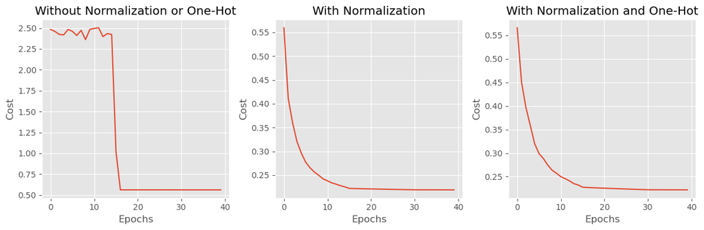

```
=================
Non-Normalized Data Loss :
Resubstitution acc: 0.2729227230845053
Validation acc: 0.2717065226707808
=================
Normalized Data Loss :
Resubstitution acc: 0.8139754148125398
Validation acc: 0.811691094540156
=================
Normalized and One-Hot Encoded Data Loss :
Resubstitution acc: 0.8197110061927244
Validation acc: 0.8166909516870946
```

```python
plt.subplots(figsize=(12, 4))

plt.subplot(1,3,1)
plt.title("Without Normalization or One-Hot")
plt.plot(range(len(nn_unalt.cost_)), nn_unalt.cost_)
plt.ylabel('Cost')
plt.xlabel('Epochs')
plt.tight_layout()

plt.subplot(1,3,2)
plt.title("With Normalization")
plt.plot(range(len(nn_norm.cost_)), nn_norm.cost_)
plt.ylabel('Cost')
plt.xlabel('Epochs')
plt.tight_layout()

plt.subplot(1,3,3)
plt.title("With Normalization and One-Hot")
plt.plot(range(len(nn_norm_OH.cost_)), nn_norm_OH.cost_)
plt.ylabel('Cost')
plt.xlabel('Epochs')
plt.tight_layout()

plt.show()

print_result(nn_unalt,X_train_unalt,y_train_unalt,X_test_unalt,y_test_unalt,title="Non-Normalized Data Loss",color="red")
print_result(nn_norm,X_train_norm,y_train_norm,X_test_norm,y_test_norm,title="Normalized Data Loss",color="red")
print_result(nn_norm_OH,X_train_norm_OH,y_train_norm_OH,X_test_norm_OH,y_test_norm_OH,title="Normalized and One-Hot Encoded Data Loss",color="red")
```

### Pre-processing and Initial Modeling Comparison

In addition to the data shown directly above, the following times were recorded for processing each version of the model:

- Without Normalization or One-Hot: CPU times: total: 2min 11s, Wall time: 43.7 s
- With Normalization: CPU times: total: 57.8 s, Wall time: 18.8 s
- With Normalization and One-Hot: CPU times: total: 1min 2s, Wall time: 22 s

The obvious take away from the above charts is the poor performance of the model without normalization or one-hot encoding. The loss function took more epochs to converge, and once it had the accuracies were only slightly better than chance, 25% for this example. Additionally, the loss function was not reduced as much (>0.50) than it was with normalization or normalization and one-hot. Processing time was the longest of the three.

The second two models are very close performance wise. The model which included one-hot encoded values took slightly longer to run. However, the end results are nearly indistinguishable. The one-hot encoding actually seemed to negatively impact the speed of convergence. At 10 epochs for example, the loss function with just normalized data was slightly lower than with normalized and one-hot encoded data. However, the accuracies for the one-hot encoded data are slightly better.

Overall the model that performs the best is the normalized and one-hot encoded version because over the course of 40 epochs it converges to approximately the same level and has higher accuracy than any other.

## 3. Modeling

### Three layers

I'll start by taking my two-layer perceptron base and adding the appropriate functionality for a third layer.

```python
# Source: Modified from above to add a third layer

import numpy as np
from scipy.special import expit
import pandas as pd
import sys

# start with a simple base classifier, which can't be fit or predicted
# it only has internal classes to be used by classes that will subclass it
class ThreeLayerPerceptronBase(TwoLayerPerceptronBase):

    def _initialize_weights(self): # implement glorot
        """Initialize weights Glorot and He normalization."""
        init_bound = 4*np.sqrt(6. / (self.n_hidden + self.n_features_))
        W1 = np.random.uniform(-init_bound, init_bound,(self.n_hidden, self.n_features_))

        # reduce the final layer magnitude in order to balance the size of the gradients
        init_bound = 4*np.sqrt(6 / (self.n_hidden + self.n_hidden)) # changed for adding 3rd layer
        W2 = np.random.uniform(-init_bound, init_bound,(self.n_hidden, self.n_hidden))

        # Add third layer
        init_bound = 4*np.sqrt(6 / (self.n_output_ + self.n_hidden))
        W3 = np.random.uniform(-init_bound, init_bound,(self.n_output_, self.n_hidden))

        # set these to zero to start so that
        # they do not immediately saturate the neurons
        b1 = np.zeros((self.n_hidden, 1))
        b2 = np.zeros((self.n_hidden, 1))
        b3 = np.zeros((self.n_output_, 1))

        return W1, W2, W3, b1, b2, b3


    @staticmethod
    def _L2_reg(lambda_, W1, W2, W3):
        """Compute L2-regularization cost"""
        # only compute for non-bias terms
        return (lambda_/2.0) * np.sqrt(np.mean(W1[:, 1:] ** 2)
                                       + np.mean(W2[:, 1:] ** 2)
                                       + np.mean(W3[:, 1:] ** 2))


    def _cost(self,A4,Y_enc,W1,W2,W3): # implement cross-entropy equation
        '''Get the objective function value'''
        cost = -np.mean(np.nan_to_num((Y_enc*np.log(A4+1e-7)+(1-Y_enc)*np.log(1-A4+1e-7))))
        L2_term = self._L2_reg(self.l2_C, W1, W2, W3)
        return cost + L2_term


    def _feedforward(self, X, W1, W2, W3, b1, b2, b3):
        """Compute feedforward step
        -----------
        X : Input layer with original features.
        W1: Weight matrix for input layer -> hidden layer.
        W2: Weight matrix for hidden layer -> output layer.
        ----------
        a1-a3 : activations into layer (or output layer)
        z1-z2 : layer inputs

        """
        A1 = X.T
        Z1 = W1 @ A1 + b1
        A2 = self._sigmoid(Z1)
        Z2 = W2 @ A2 + b2
        A3 = self._sigmoid(Z2)
        Z3 = W3 @ A3 + b3
        A4 = self._sigmoid(Z3)
        return A1, Z1, A2, Z2, A3, Z3, A4


    # Replaced get gradient function from lecture with cross-entropy version
    def _get_gradient(self, A1, A2, A3, A4, Z1, Z2, Z3, Y_enc, W1, W2, W3):
        """ Compute gradient step using backpropagation.
        """
        # vectorized backpropagation and V2 for cross-entropy
        V3 = (A4-Y_enc)
        V2 = A3*(1-A3)*(W3.T @ V3)
        V1 = A2*(1-A2)*(W2.T @ V2)

        gradW3 = V3 @ A3.T
        gradW2 = V2 @ A2.T
        gradW1 = V1 @ A1.T

        gradb3 = np.sum(V3, axis=1).reshape((-1,1))
        gradb2 = np.sum(V2, axis=1).reshape((-1,1))
        gradb1 = np.sum(V1, axis=1).reshape((-1,1))

        # regularize weights that are not bias terms
        gradW1 += W1 * self.l2_C
        gradW2 += W2 * self.l2_C
        gradW3 += W3 * self.l2_C

        return gradW1, gradW2, gradW3, gradb1, gradb2, gradb3


    def predict(self, X):
        """Predict class labels"""
        _, _, _, _, _, _, A4 = self._feedforward(X, self.W1, self.W2, self.W3, self.b1, self.b2, self.b3)
        y_pred = np.argmax(A4, axis=0)
        return y_pred
```

```python
# Source: Modified from above

from sklearn.metrics import accuracy_score
# just start with the vectorized version and minibatch
class TLPMiniBatch_3(ThreeLayerPerceptronBase):
    def __init__(self, alpha=0.0, decrease_const=0.1,
                 decrease_iter = 10, shuffle=True,
                 minibatches=1, **kwds):
        # need to add to the original initializer
        self.alpha = alpha
        self.decrease_const = decrease_const
        self.decrease_iter = decrease_iter
        self.shuffle = shuffle
        self.minibatches = minibatches
        # but keep other keywords
        super().__init__(**kwds)


    def fit(self, X, y, print_progress=False, XY_test=None):
        """ Learn weights from training data. With mini-batch"""
        X_data, y_data = X.copy(), y.copy()
        Y_enc = self._encode_labels(y)

        # init weights and setup matrices
        self.n_features_ = X_data.shape[1]
        self.n_output_ = Y_enc.shape[0]
        self.W1, self.W2, self.W3, self.b1, self.b2, self.b3 = self._initialize_weights()

        # Establish gradient magnitude tracking arrays
        self.grad_w1_ = np.zeros(self.epochs)
        self.grad_w2_ = np.zeros(self.epochs)
        self.grad_w3_ = np.zeros(self.epochs)

        # start momentum at zero for previous updates
        rho_W1_prev = np.zeros(self.W1.shape) # for momentum
        rho_W2_prev = np.zeros(self.W2.shape) # for momentum
        rho_W3_prev = np.zeros(self.W3.shape)

        self.cost_ = []
        self.score_ = []
        # get starting acc
        self.score_.append(accuracy_score(y_data,self.predict(X_data)))

        # keep track of validation, if given
        if XY_test is not None:
            X_test = XY_test[0].copy()
            y_test = XY_test[1].copy()
            self.val_score_ = []
            self.val_score_.append(accuracy_score(y_test,self.predict(X_test)))
            self.val_cost_ = []

        for i in range(self.epochs):

            # adaptive learning rate
            # decrease at certain epochs
            eta = self.eta * self.decrease_const**(np.floor(i/self.decrease_iter))

            if print_progress>0 and (i+1)%print_progress==0:
                sys.stderr.write('\rEpoch: %d/%d' % (i+1, self.epochs))
                sys.stderr.flush()

            if self.shuffle:
                idx_shuffle = np.random.permutation(y_data.shape[0])
                X_data, Y_enc, y_data = X_data[idx_shuffle], Y_enc[:, idx_shuffle], y_data[idx_shuffle]

            mini = np.array_split(range(y_data.shape[0]), self.minibatches)
            mini_cost = []
            for idx in mini:

                # feedforward
                A1, Z1, A2, Z2, A3, Z3, A4 = self._feedforward(X_data[idx],
                                                               self.W1,
                                                               self.W2,
                                                               self.W3,
                                                               self.b1,
                                                               self.b2,
                                                               self.b3
                                                              )

                cost = self._cost(A4,Y_enc[:, idx],self.W1,self.W2,self.W3)
                mini_cost.append(cost) # this appends cost of mini-batch only

                # compute gradient via backpropagation
                gradW1, gradW2, gradW3, gradb1, gradb2, gradb3 = self._get_gradient(A1=A1,
                                                                                    A2=A2,
                                                                                    A3=A3,
                                                                                    A4=A4,
                                                                                    Z1=Z1,
                                                                                    Z2=Z2,
                                                                                    Z3=Z3,
                                                                                    Y_enc=Y_enc[:, idx],
                                                                                    W1=self.W1,
                                                                                    W2=self.W2,
                                                                                    W3=self.W3
                                                                                   )

                # add support for tracking the magnitude of the gradients
                def grad_w1_(gradW1):
                    self.grad_w1_[i] = np.mean(np.abs(gradW1))

                    return grad_w1_


                def grad_w2_(gradW2):
                    self.grad_w2_[i] = np.mean(np.abs(gradW2))

                    return grad_w2_


                def grad_w3_(gradW3):
                    self.grad_w3_[i] = np.mean(np.abs(gradW3))

                    return grad_w3_

                # Track the magnitude of the gradient
                grad_w1_(gradW1)
                grad_w2_(gradW2)
                grad_w3_(gradW3)

                # simple momentum calculations
                rho_W1, rho_W2, rho_W3 = eta * gradW1, eta * gradW2, eta * gradW3
                self.W1 -= (rho_W1 + (self.alpha * rho_W1_prev)) # update with momentum
                self.W2 -= (rho_W2 + (self.alpha * rho_W2_prev)) # update with momentum
                self.W3 -= (rho_W3 + (self.alpha * rho_W3_prev)) # update with momentum

                # no need for momentum in bias
                # these values need to change abruptly and
                # do not influence sensitivity backward
                self.b1 -= eta * gradb1
                self.b2 -= eta * gradb2
                self.b3 -= eta * gradb3

                # update previous parameters
                rho_W1_prev, rho_W2_prev, rho_W3_prev = rho_W1, rho_W2, rho_W3

            self.cost_.append(np.mean(mini_cost))
            self.score_.append(accuracy_score(y_data,self.predict(X_data)))

            # update if a validation set was provided
            if XY_test is not None:
                yhat = self.predict(X_test)
                self.val_score_.append(accuracy_score(y_test,yhat))

        return self
```

```python
nn_3 = TLPMiniBatch_3(**vals)

%time nn_3.fit(X_train_norm_OH, y_train_norm_OH, print_progress=1, XY_test=(X_test_norm_OH, y_test_norm_OH))
yhat = nn_3.predict(X_train_norm_OH)
```

```
Epoch: 40/40
```

```
CPU times: total: 2min 1s
Wall time: 36.9 s
```

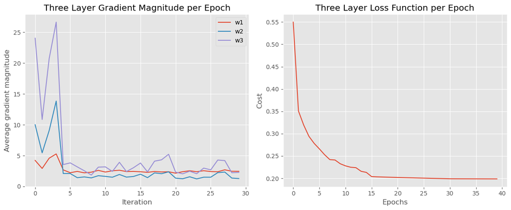

```
=================
Three-Layer Data Loss :
Resubstitution acc: 0.8366963565066463
Validation acc: 0.8311191108825462
```

```python
plt.subplots(figsize=(12, 5))

# ax = plt.subplot(1,2,1)
plt.subplot(1,2,1)
plt.plot(np.abs(nn_3.grad_w1_[10:]), label='w1')
plt.plot(np.abs(nn_3.grad_w2_[10:]), label='w2')
plt.plot(np.abs(nn_3.grad_w3_[10:]), label='w3')
plt.legend()
plt.title('Three Layer Gradient Magnitude per Epoch')
plt.ylabel('Average gradient magnitude')
plt.xlabel('Iteration')

plt.subplot(1,2,2)
plt.plot(range(len(nn_3.cost_)), nn_3.cost_)
plt.ylabel('Cost')
plt.xlabel('Epochs')
plt.title('Three Layer Loss Function per Epoch')
plt.tight_layout()
plt.show()

plt.show()

print_result(nn_3,X_train_norm_OH,y_train_norm_OH,X_test_norm_OH,y_test_norm_OH,title="Three-Layer Data Loss",color="red")
```

### 4 Layers

```python
# FrankenBase
# Source: Modified from in-class lecture

import numpy as np
from scipy.special import expit
import pandas as pd
import sys

# start with a simple base classifier, which can't be fit or predicted
# it only has internal classes to be used by classes that will subclass it
class FourLayerPerceptronBase(ThreeLayerPerceptronBase):

    def _initialize_weights(self): # implement glorot
        """Initialize weights Glorot and He normalization."""
        init_bound = 4*np.sqrt(6. / (self.n_hidden + self.n_features_))
        W1 = np.random.uniform(-init_bound, init_bound,(self.n_hidden, self.n_features_))

        # reduce the final layer magnitude in order to balance the size of the gradients
        # between
        init_bound = 4*np.sqrt(6 / (self.n_hidden + self.n_hidden)) # changed for adding 3rd layer
        W2 = np.random.uniform(-init_bound, init_bound,(self.n_hidden, self.n_hidden))

        # Add fourth layer
        init_bound = 4*np.sqrt(6 / (self.n_hidden + self.n_hidden)) # changed for adding 3rd layer
        W3 = np.random.uniform(-init_bound, init_bound,(self.n_hidden, self.n_hidden))

        # Add third layer
        init_bound = 4*np.sqrt(6 / (self.n_output_ + self.n_hidden))
        W4 = np.random.uniform(-init_bound, init_bound,(self.n_output_, self.n_hidden))


        # set these to zero to start so that
        # they do not immediately saturate the neurons
        b1 = np.zeros((self.n_hidden, 1))
        b2 = np.zeros((self.n_hidden, 1))
        b3 = np.zeros((self.n_hidden, 1))
        b4 = np.zeros((self.n_output_, 1))

        return W1, W2, W3, W4, b1, b2, b3, b4


    @staticmethod
    def _L2_reg(lambda_, W1, W2, W3, W4):
        """Compute L2-regularization cost"""
        # only compute for non-bias terms
        return (lambda_/2.0) * np.sqrt(np.mean(W1[:, 1:] ** 2)
                                       + np.mean(W2[:, 1:] ** 2)
                                       + np.mean(W3[:, 1:] ** 2)
                                       + np.mean(W4[:, 1:] ** 2))


    def _cost(self,A5,Y_enc,W1,W2,W3,W4): # implement cross-entropy equation
        '''Get the objective function value'''
        cost = -np.mean(np.nan_to_num((Y_enc*np.log(A5+1e-7)+(1-Y_enc)*np.log(1-A5+1e-7))))
        L2_term = self._L2_reg(self.l2_C, W1, W2, W3, W4)
        return cost + L2_term


    def _feedforward(self, X, W1, W2, W3, W4, b1, b2, b3, b4):
        """Compute feedforward step
        -----------
        X : Input layer with original features.
        W1: Weight matrix for input layer -> hidden layer.
        W2: Weight matrix for hidden layer -> output layer.
        ----------
        a1-a3 : activations into layer (or output layer)
        z1-z2 : layer inputs

        """
        A1 = X.T
        Z1 = W1 @ A1 + b1
        A2 = self._sigmoid(Z1)
        Z2 = W2 @ A2 + b2
        A3 = self._sigmoid(Z2)
        Z3 = W3 @ A3 + b3
        A4 = self._sigmoid(Z3)
        Z4 = W4 @ A4 + b4
        A5 = self._sigmoid(Z4)
        return A1, Z1, A2, Z2, A3, Z3, A4, Z4, A5


    # Replaced get gradient function from lecture with cross-entropy version
    def _get_gradient(self, A1, A2, A3, A4, A5, Z1, Z2, Z3, Z4, Y_enc, W1, W2, W3, W4):
        """ Compute gradient step using backpropagation.
        """
        # vectorized backpropagation and V2 for cross-entropy
        V4 = (A5-Y_enc)
        V3 = A4*(1-A4)*(W4.T @ V4)
        V2 = A3*(1-A3)*(W3.T @ V3)
        V1 = A2*(1-A2)*(W2.T @ V2)

        gradW4 = V4 @ A4.T
        gradW3 = V3 @ A3.T
        gradW2 = V2 @ A2.T
        gradW1 = V1 @ A1.T

        gradb4 = np.sum(V4, axis=1).reshape((-1,1))
        gradb3 = np.sum(V3, axis=1).reshape((-1,1))
        gradb2 = np.sum(V2, axis=1).reshape((-1,1))
        gradb1 = np.sum(V1, axis=1).reshape((-1,1))

        # regularize weights that are not bias terms
        gradW1 += W1 * self.l2_C
        gradW2 += W2 * self.l2_C
        gradW3 += W3 * self.l2_C
        gradW4 += W4 * self.l2_C

        return gradW1, gradW2, gradW3, gradW4, gradb1, gradb2, gradb3, gradb4


    def predict(self, X):
        """Predict class labels"""
        _, _, _, _, _, _, _, _, A5 = self._feedforward(
                                                 X,
                                                 self.W1,
                                                 self.W2,
                                                 self.W3,
                                                 self.W4,
                                                 self.b1,
                                                 self.b2,
                                                 self.b3,
                                                 self.b4
                                                )
        y_pred = np.argmax(A5, axis=0)
        return y_pred
```

```python
from sklearn.metrics import accuracy_score
# just start with the vectorized version and minibatch
class TLPMiniBatch_4(FourLayerPerceptronBase):
    def __init__(self, alpha=0.0, decrease_const=0.1,
                 decrease_iter = 10, shuffle=True,
                 minibatches=1, **kwds):
        # need to add to the original initializer
        self.alpha = alpha
        self.decrease_const = decrease_const
        self.decrease_iter = decrease_iter
        self.shuffle = shuffle
        self.minibatches = minibatches
        # but keep other keywords
        super().__init__(**kwds)


    def fit(self, X, y, print_progress=False, XY_test=None):
        """ Learn weights from training data. With mini-batch"""
        X_data, y_data = X.copy(), y.copy()
        Y_enc = self._encode_labels(y)

        # init weights and setup matrices
        self.n_features_ = X_data.shape[1]
        self.n_output_ = Y_enc.shape[0]
        self.W1, self.W2, self.W3, self.W4, self.b1, self.b2, self.b3, self.b4 = self._initialize_weights()

        # Establish gradient magnitude tracking arrays
        self.grad_w1_ = np.zeros(self.epochs)
        self.grad_w2_ = np.zeros(self.epochs)
        self.grad_w3_ = np.zeros(self.epochs)
        self.grad_w4_ = np.zeros(self.epochs)

        # start momentum at zero for previous updates
        rho_W1_prev = np.zeros(self.W1.shape) # for momentum
        rho_W2_prev = np.zeros(self.W2.shape) # for momentum
        rho_W3_prev = np.zeros(self.W3.shape)
        rho_W4_prev = np.zeros(self.W4.shape)

        self.cost_ = []
        self.score_ = []
        # get starting acc
        self.score_.append(accuracy_score(y_data,self.predict(X_data)))
        # keep track of validation, if given
        if XY_test is not None:
            X_test = XY_test[0].copy()
            y_test = XY_test[1].copy()
            self.val_score_ = []
            self.val_score_.append(accuracy_score(y_test,self.predict(X_test)))
            self.val_cost_ = []

        for i in range(self.epochs):

            # adaptive learning rate
            # decrease at certain epochs
            eta = self.eta * self.decrease_const**(np.floor(i/self.decrease_iter))

            if print_progress>0 and (i+1)%print_progress==0:
                sys.stderr.write('\rEpoch: %d/%d' % (i+1, self.epochs))
                sys.stderr.flush()

            if self.shuffle:
                idx_shuffle = np.random.permutation(y_data.shape[0])
                X_data, Y_enc, y_data = X_data[idx_shuffle], Y_enc[:, idx_shuffle], y_data[idx_shuffle]

            mini = np.array_split(range(y_data.shape[0]), self.minibatches)
            mini_cost = []
            for idx in mini:

                # feedforward
                A1, Z1, A2, Z2, A3, Z3, A4, Z4, A5 = self._feedforward(
                                                       X_data[idx],
                                                       self.W1,
                                                       self.W2,
                                                       self.W3,
                                                       self.W4,
                                                       self.b1,
                                                       self.b2,
                                                       self.b3,
                                                       self.b4
                                                      )

                cost = self._cost(A5,Y_enc[:, idx],self.W1,self.W2,self.W3,self.W4)
                mini_cost.append(cost) # this appends cost of mini-batch only

                # compute gradient via backpropagation
                gradW1, gradW2, gradW3, gradW4, gradb1, gradb2, gradb3, gradb4 = self._get_gradient(
                                                                                    A1=A1,
                                                                                    A2=A2,
                                                                                    A3=A3,
                                                                                    A4=A4,
                                                                                    A5=A5,
                                                                                    Z1=Z1,
                                                                                    Z2=Z2,
                                                                                    Z3=Z3,
                                                                                    Z4=Z4,
                                                                                    Y_enc=Y_enc[:, idx],
                                                                                    W1=self.W1,
                                                                                    W2=self.W2,
                                                                                    W3=self.W3,
                                                                                    W4=self.W4)


                # add support for tracking the magnitude of the gradients
                def grad_w1_(gradW1):
                    self.grad_w1_[i] = np.mean(np.abs(gradW1))

                    return grad_w1_


                def grad_w2_(gradW2):
                    self.grad_w2_[i] = np.mean(np.abs(gradW2))

                    return grad_w2_


                def grad_w3_(gradW3):
                    self.grad_w3_[i] = np.mean(np.abs(gradW3))

                    return grad_w3_


                def grad_w4_(gradW4):
                    self.grad_w4_[i] = np.mean(np.abs(gradW4))

                    return grad_w4_

                # Track the magnitude of the gradient
                grad_w1_(gradW1)
                grad_w2_(gradW2)
                grad_w3_(gradW3)
                grad_w4_(gradW4)

                # simple momentum calculations
                rho_W1, rho_W2, rho_W3, rho_W4 = eta * gradW1, eta * gradW2, eta * gradW3, eta * gradW4
                self.W1 -= (rho_W1 + (self.alpha * rho_W1_prev)) # update with momentum
                self.W2 -= (rho_W2 + (self.alpha * rho_W2_prev)) # update with momentum
                self.W3 -= (rho_W3 + (self.alpha * rho_W3_prev)) # update with momentum
                self.W4 -= (rho_W4 + (self.alpha * rho_W4_prev)) # update with momentum


                # no need for momentum in bias
                # these values need to change abruptly and
                # do not influence sensitivity backward
                self.b1 -= eta * gradb1
                self.b2 -= eta * gradb2
                self.b3 -= eta * gradb3
                self.b4 -= eta * gradb4

                # update previous parameters
                rho_W1_prev, rho_W2_prev, rho_W3_prev, rho_W4_prev = rho_W1, rho_W2, rho_W3, rho_W4



            self.cost_.append(np.mean(mini_cost))
            self.score_.append(accuracy_score(y_data,self.predict(X_data)))

            # update if a validation set was provided
            if XY_test is not None:
                yhat = self.predict(X_test)
                self.val_score_.append(accuracy_score(y_test,yhat))

        return self
```

```python
nn_4 = TLPMiniBatch_4(**vals)

%time nn_4.fit(X_train_norm_OH, y_train_norm_OH, print_progress=1, XY_test=(X_test_norm_OH, y_test_norm_OH))
yhat = nn_4.predict(X_train_norm_OH)
```

```
Epoch: 40/40
```

```
CPU times: total: 2min 55s
Wall time: 52.1 s
```

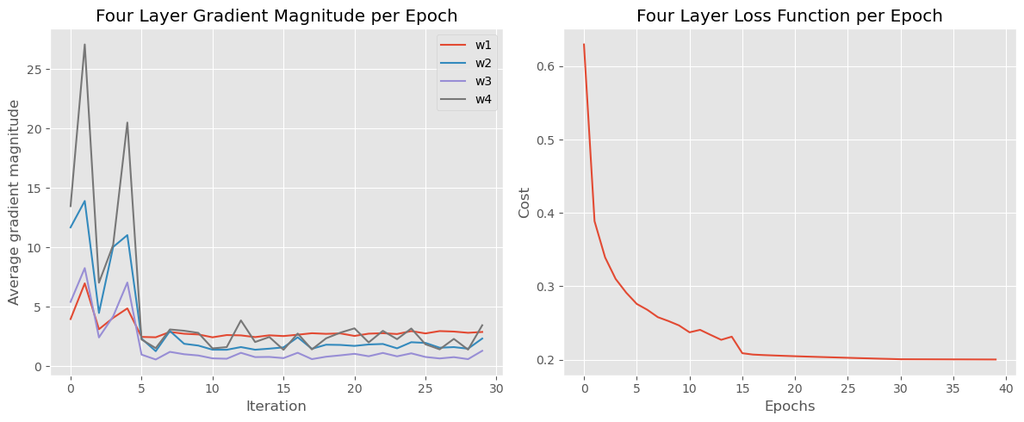

```
=================
Four-Layer Data Loss :
Resubstitution acc: 0.8359463725777305
Validation acc: 0.8301477100654266
```

```python
plt.subplots(figsize=(12, 5))

plt.subplot(1,2,1)
plt.plot(np.abs(nn_4.grad_w1_[10:]), label='w1')
plt.plot(np.abs(nn_4.grad_w2_[10:]), label='w2')
plt.plot(np.abs(nn_4.grad_w3_[10:]), label='w3')
plt.plot(np.abs(nn_4.grad_w4_[10:]), label='w4')
plt.legend()
plt.title('Four Layer Gradient Magnitude per Epoch')
plt.ylabel('Average gradient magnitude')
plt.xlabel('Iteration')

plt.subplot(1,2,2)
plt.plot(range(len(nn_4.cost_)), nn_4.cost_)
plt.ylabel('Cost')
plt.xlabel('Epochs')
plt.title('Four Layer Loss Function per Epoch')
plt.tight_layout()
plt.show()

plt.show()

print_result(nn_4,X_train_norm_OH,y_train_norm_OH,X_test_norm_OH,y_test_norm_OH,title="Four-Layer Data Loss",color="red")
```

### Five Layers

```python
# FrankenBase
# Source: Modified from in-class lecture

import numpy as np
from scipy.special import expit
import pandas as pd
import sys

# start with a simple base classifier, which can't be fit or predicted
# it only has internal classes to be used by classes that will subclass it
class FiveLayerPerceptronBase(FourLayerPerceptronBase):

    def _initialize_weights(self): # implement glorot
        """Initialize weights Glorot and He normalization."""
        init_bound = 4*np.sqrt(6. / (self.n_hidden + self.n_features_))
        W1 = np.random.uniform(-init_bound, init_bound,(self.n_hidden, self.n_features_))

        # reduce the final layer magnitude in order to balance the size of the gradients
        # between
        init_bound = 4*np.sqrt(6 / (self.n_hidden + self.n_hidden)) # changed for adding 3rd layer
        W2 = np.random.uniform(-init_bound, init_bound,(self.n_hidden, self.n_hidden))

        # Add fourth layer
        init_bound = 4*np.sqrt(6 / (self.n_hidden + self.n_hidden)) # changed for adding 3rd layer
        W3 = np.random.uniform(-init_bound, init_bound,(self.n_hidden, self.n_hidden))

        # Add fifth layer
        init_bound = 4*np.sqrt(6 / (self.n_hidden + self.n_hidden)) # changed for adding 3rd layer
        W4 = np.random.uniform(-init_bound, init_bound,(self.n_hidden, self.n_hidden))

        # Add third layer
        init_bound = 4*np.sqrt(6 / (self.n_output_ + self.n_hidden))
        W5 = np.random.uniform(-init_bound, init_bound,(self.n_output_, self.n_hidden))


        # set these to zero to start so that
        # they do not immediately saturate the neurons
        b1 = np.zeros((self.n_hidden, 1))
        b2 = np.zeros((self.n_hidden, 1))
        b3 = np.zeros((self.n_hidden, 1))
        b4 = np.zeros((self.n_hidden, 1))
        b5 = np.zeros((self.n_output_, 1))

        return W1, W2, W3, W4, W5, b1, b2, b3, b4, b5


    @staticmethod
    def _L2_reg(lambda_, W1, W2, W3, W4, W5):
        """Compute L2-regularization cost"""
        # only compute for non-bias terms
        return (lambda_/2.0) * np.sqrt(np.mean(W1[:, 1:] ** 2)
                                       + np.mean(W2[:, 1:] ** 2)
                                       + np.mean(W3[:, 1:] ** 2)
                                       + np.mean(W4[:, 1:] ** 2)
                                       + np.mean(W5[:, 1:] ** 2))


    def _cost(self,A6,Y_enc,W1,W2,W3,W4,W5): # implement cross-entropy equation
        '''Get the objective function value'''
        cost = -np.mean(np.nan_to_num((Y_enc*np.log(A6+1e-7)+(1-Y_enc)*np.log(1-A6+1e-7))))
        L2_term = self._L2_reg(self.l2_C, W1, W2, W3, W4, W5)
        return cost + L2_term


    def _feedforward(self, X, W1, W2, W3, W4, W5, b1, b2, b3, b4, b5):
        """Compute feedforward step
        -----------
        X : Input layer with original features.
        W1: Weight matrix for input layer -> hidden layer.
        W2: Weight matrix for hidden layer -> output layer.
        ----------
        a1-a3 : activations into layer (or output layer)
        z1-z2 : layer inputs

        """
        A1 = X.T
        Z1 = W1 @ A1 + b1
        A2 = self._sigmoid(Z1)
        Z2 = W2 @ A2 + b2
        A3 = self._sigmoid(Z2)
        Z3 = W3 @ A3 + b3
        A4 = self._sigmoid(Z3)
        Z4 = W4 @ A4 + b4
        A5 = self._sigmoid(Z4)
        Z5 = W5 @ A5 + b5
        A6 = self._sigmoid(Z5)

        return A1, Z1, A2, Z2, A3, Z3, A4, Z4, A5, Z5, A6


    # Replaced get gradient function from lecture with cross-entropy version
    def _get_gradient(self, A1, A2, A3, A4, A5, A6, Z1, Z2, Z3, Z4, Z5, Y_enc, W1, W2, W3, W4, W5):
        """ Compute gradient step using backpropagation.
        """
        # vectorized backpropagation and V2 for cross-entropy
        V5 = (A6-Y_enc)
        V4 = A5*(1-A5)*(W5.T @ V5)
        V3 = A4*(1-A4)*(W4.T @ V4)
        V2 = A3*(1-A3)*(W3.T @ V3)
        V1 = A2*(1-A2)*(W2.T @ V2)

        gradW5 = V5 @ A5.T
        gradW4 = V4 @ A4.T
        gradW3 = V3 @ A3.T
        gradW2 = V2 @ A2.T
        gradW1 = V1 @ A1.T

        gradb5 = np.sum(V5, axis=1).reshape((-1,1))
        gradb4 = np.sum(V4, axis=1).reshape((-1,1))
        gradb3 = np.sum(V3, axis=1).reshape((-1,1))
        gradb2 = np.sum(V2, axis=1).reshape((-1,1))
        gradb1 = np.sum(V1, axis=1).reshape((-1,1))

        # regularize weights that are not bias terms
        gradW1 += W1 * self.l2_C
        gradW2 += W2 * self.l2_C
        gradW3 += W3 * self.l2_C
        gradW4 += W4 * self.l2_C
        gradW5 += W5 * self.l2_C

        return gradW1, gradW2, gradW3, gradW4, gradW5, gradb1, gradb2, gradb3, gradb4, gradb5


    def predict(self, X):
        """Predict class labels"""
        _, _, _, _, _, _, _, _, _, _, A6 = self._feedforward(
                                                 X,
                                                 self.W1,
                                                 self.W2,
                                                 self.W3,
                                                 self.W4,
                                                 self.W5,
                                                 self.b1,
                                                 self.b2,
                                                 self.b3,
                                                 self.b4,
                                                 self.b5
                                                )
        y_pred = np.argmax(A6, axis=0)
        return y_pred
```

```python
# FrankenBatch

from sklearn.metrics import accuracy_score
# just start with the vectorized version and minibatch
class TLPMiniBatch_5(FiveLayerPerceptronBase):
    def __init__(self, alpha=0.0, decrease_const=0.1,
                 decrease_iter = 10, shuffle=True,
                 minibatches=1, **kwds):
        # need to add to the original initializer
        self.alpha = alpha
        self.decrease_const = decrease_const
        self.decrease_iter = decrease_iter
        self.shuffle = shuffle
        self.minibatches = minibatches
        # but keep other keywords
        super().__init__(**kwds)


    def fit(self, X, y, print_progress=False, XY_test=None):
        """ Learn weights from training data. With mini-batch"""
        X_data, y_data = X.copy(), y.copy()
        Y_enc = self._encode_labels(y)

        # init weights and setup matrices
        self.n_features_ = X_data.shape[1]
        self.n_output_ = Y_enc.shape[0]
        self.W1, self.W2, self.W3, self.W4, self.W5, self.b1, self.b2, self.b3, self.b4, self.b5 = self._initialize_weights()

        # Establish gradient magnitude tracking arrays
        self.grad_w1_ = np.zeros(self.epochs)
        self.grad_w2_ = np.zeros(self.epochs)
        self.grad_w3_ = np.zeros(self.epochs)
        self.grad_w4_ = np.zeros(self.epochs)
        self.grad_w5_ = np.zeros(self.epochs)

        # start momentum at zero for previous updates
        rho_W1_prev = np.zeros(self.W1.shape) # for momentum
        rho_W2_prev = np.zeros(self.W2.shape) # for momentum
        rho_W3_prev = np.zeros(self.W3.shape)
        rho_W4_prev = np.zeros(self.W4.shape)
        rho_W5_prev = np.zeros(self.W5.shape)

        self.cost_ = []
        self.score_ = []
        # get starting acc
        self.score_.append(accuracy_score(y_data,self.predict(X_data)))
        # keep track of validation, if given
        if XY_test is not None:
            X_test = XY_test[0].copy()
            y_test = XY_test[1].copy()
            self.val_score_ = []
            self.val_score_.append(accuracy_score(y_test,self.predict(X_test)))
            self.val_cost_ = []

        for i in range(self.epochs):

            # adaptive learning rate
            # decrease at certain epochs
            eta = self.eta * self.decrease_const**(np.floor(i/self.decrease_iter))

            if print_progress>0 and (i+1)%print_progress==0:
                sys.stderr.write('\rEpoch: %d/%d' % (i+1, self.epochs))
                sys.stderr.flush()

            if self.shuffle:
                idx_shuffle = np.random.permutation(y_data.shape[0])
                X_data, Y_enc, y_data = X_data[idx_shuffle], Y_enc[:, idx_shuffle], y_data[idx_shuffle]

            mini = np.array_split(range(y_data.shape[0]), self.minibatches)
            mini_cost = []
            for idx in mini:

                # feedforward
                A1, Z1, A2, Z2, A3, Z3, A4, Z4, A5, Z5, A6 = self._feedforward(
                                                       X_data[idx],
                                                       self.W1,
                                                       self.W2,
                                                       self.W3,
                                                       self.W4,
                                                       self.W5,
                                                       self.b1,
                                                       self.b2,
                                                       self.b3,
                                                       self.b4,
                                                       self.b5
                                                      )

                cost = self._cost(A6,Y_enc[:, idx],self.W1,self.W2,self.W3,self.W4,self.W5)
                mini_cost.append(cost) # this appends cost of mini-batch only

                # compute gradient via backpropagation
                gradW1, gradW2, gradW3, gradW4, gradW5, gradb1, gradb2, gradb3, gradb4, gradb5 = self._get_gradient(
                                                                                    A1=A1,
                                                                                    A2=A2,
                                                                                    A3=A3,
                                                                                    A4=A4,
                                                                                    A5=A5,
                                                                                    A6=A6,
                                                                                    Z1=Z1,
                                                                                    Z2=Z2,
                                                                                    Z3=Z3,
                                                                                    Z4=Z4,
                                                                                    Z5=Z5,
                                                                                    Y_enc=Y_enc[:, idx],
                                                                                    W1=self.W1,
                                                                                    W2=self.W2,
                                                                                    W3=self.W3,
                                                                                    W4=self.W4,
                                                                                    W5=self.W5)


                # add support for tracking the magnitude of the gradients
                def grad_w1_(gradW1):
                    self.grad_w1_[i] = np.mean(np.abs(gradW1))

                    return grad_w1_


                def grad_w2_(gradW2):
                    self.grad_w2_[i] = np.mean(np.abs(gradW2))

                    return grad_w2_


                def grad_w3_(gradW3):
                    self.grad_w3_[i] = np.mean(np.abs(gradW3))

                    return grad_w3_


                def grad_w4_(gradW4):
                    self.grad_w4_[i] = np.mean(np.abs(gradW4))

                    return grad_w4_


                def grad_w5_(gradW5):
                    self.grad_w5_[i] = np.mean(np.abs(gradW5))

                    return grad_w5_

                # Track the magnitude of the gradient
                grad_w1_(gradW1)
                grad_w2_(gradW2)
                grad_w3_(gradW3)
                grad_w4_(gradW4)
                grad_w5_(gradW5)


                # simple momentum calculations
                rho_W1, rho_W2, rho_W3, rho_W4, rho_W5 = eta * gradW1, eta * gradW2, eta * gradW3, eta * gradW4, eta * gradW5
                self.W1 -= (rho_W1 + (self.alpha * rho_W1_prev)) # update with momentum
                self.W2 -= (rho_W2 + (self.alpha * rho_W2_prev)) # update with momentum
                self.W3 -= (rho_W3 + (self.alpha * rho_W3_prev)) # update with momentum
                self.W4 -= (rho_W4 + (self.alpha * rho_W4_prev)) # update with momentum
                self.W5 -= (rho_W5 + (self.alpha * rho_W5_prev)) # update with momentum


                # no need for momentum in bias
                # these values need to change abruptly and
                # do not influence sensitivity backward
                self.b1 -= eta * gradb1
                self.b2 -= eta * gradb2
                self.b3 -= eta * gradb3
                self.b4 -= eta * gradb4
                self.b5 -= eta * gradb5

                # update previous parameters
                rho_W1_prev, rho_W2_prev, rho_W3_prev, rho_W4_prev, rho_W5_prev = rho_W1, rho_W2, rho_W3, rho_W4, rho_W5



            self.cost_.append(np.mean(mini_cost))
            self.score_.append(accuracy_score(y_data,self.predict(X_data)))

            # update if a validation set was provided
            if XY_test is not None:
                yhat = self.predict(X_test)
                self.val_score_.append(accuracy_score(y_test,yhat))

        return self
```

```python
nn_5 = TLPMiniBatch_5(**vals)

%time nn_5.fit(X_train_norm_OH, y_train_norm_OH, print_progress=1, XY_test=(X_test_norm_OH, y_test_norm_OH))
yhat = nn_5.predict(X_train_norm_OH)
```

```
Epoch: 40/40
```

```
CPU times: total: 3min 12s
Wall time: 1min 6s
```

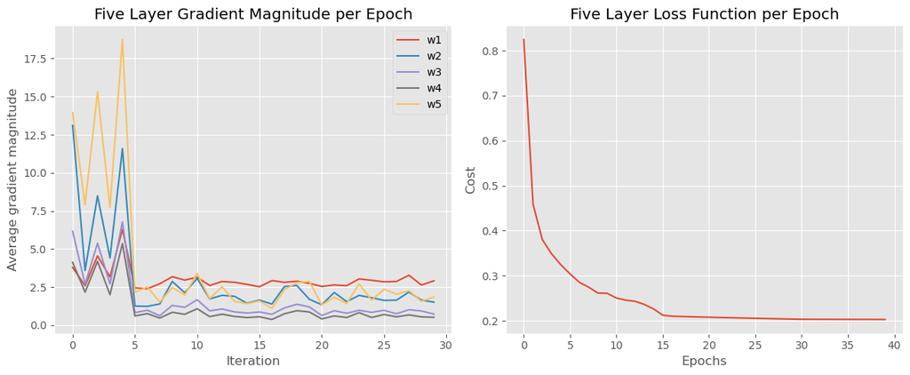

```
=================
Five-Layer Data Loss :
Resubstitution acc: 0.834510689056663
Validation acc: 0.8295191565955259
```

```python
plt.subplots(figsize=(12, 5))

plt.subplot(1,2,1)
plt.plot(np.abs(nn_5.grad_w1_[10:]), label='w1')
plt.plot(np.abs(nn_5.grad_w2_[10:]), label='w2')
plt.plot(np.abs(nn_5.grad_w3_[10:]), label='w3')
plt.plot(np.abs(nn_5.grad_w4_[10:]), label='w4')
plt.plot(np.abs(nn_5.grad_w5_[10:]), label='w5')
plt.legend()
plt.title('Five Layer Gradient Magnitude per Epoch')
plt.ylabel('Average gradient magnitude')
plt.xlabel('Iteration')

plt.subplot(1,2,2)
plt.plot(range(len(nn_5.cost_)), nn_5.cost_)
plt.ylabel('Cost')
plt.xlabel('Epochs')
plt.title('Five Layer Loss Function per Epoch')
plt.tight_layout()
plt.show()

plt.show()

print_result(nn_5,X_train_norm_OH,y_train_norm_OH,X_test_norm_OH,y_test_norm_OH,title="Five-Layer Data Loss",color="red")
```

### Adding RMS Prop

```python
# Source: Modified from in-class lecture for RMS Prop
class TLP_RMSProp(TLPMiniBatch_5):
    def fit(self, X, y, print_progress=False, XY_test=None):
        """ Learn weights from training data. With mini-batch"""
        X_data, y_data = X.copy(), y.copy()
        Y_enc = self._encode_labels(y)

        # init weights and setup matrices
        self.n_features_ = X_data.shape[1]
        self.n_output_ = Y_enc.shape[0]
        self.W1, self.W2, self.W3, self.W4, self.W5, self.b1, self.b2, self.b3, self.b4, self.b5 = self._initialize_weights()

        # Establish gradient magnitude tracking arrays
        self.grad_w1_ = np.zeros(self.epochs)
        self.grad_w2_ = np.zeros(self.epochs)
        self.grad_w3_ = np.zeros(self.epochs)
        self.grad_w4_ = np.zeros(self.epochs)
        self.grad_w5_ = np.zeros(self.epochs)

        # start momentum at zero for previous updates
        rho_W1_prev = np.zeros(self.W1.shape)
        rho_W2_prev = np.zeros(self.W2.shape)
        rho_W3_prev = np.zeros(self.W3.shape)
        rho_W4_prev = np.zeros(self.W4.shape)
        rho_W5_prev = np.zeros(self.W5.shape)

        # Adding adaptive V for entire gradient
        V1_prev = np.zeros(self.W1.shape) # for adaptive
        V2_prev = np.zeros(self.W2.shape) # for adaptive
        V3_prev = np.zeros(self.W3.shape) # for adaptive
        V4_prev = np.zeros(self.W4.shape) # for adaptive
        V5_prev = np.zeros(self.W5.shape) # for adaptive

        self.cost_ = []
        self.score_ = []
        # get starting acc
        self.score_.append(accuracy_score(y_data,self.predict(X_data)))
        # keep track of validation, if given
        if XY_test is not None:
            X_test = XY_test[0].copy()
            y_test = XY_test[1].copy()
            self.val_score_ = []
            self.val_score_.append(accuracy_score(y_test,self.predict(X_test)))
            self.val_cost_ = []

        for i in range(self.epochs):

            # adaptive learning rate
            # decrease at certain epochs
            eta = self.eta * self.decrease_const**(np.floor(i/self.decrease_iter))

            if print_progress>0 and (i+1)%print_progress==0:
                sys.stderr.write('\rEpoch: %d/%d' % (i+1, self.epochs))
                sys.stderr.flush()

            if self.shuffle:
                idx_shuffle = np.random.permutation(y_data.shape[0])
                X_data, Y_enc, y_data = X_data[idx_shuffle], Y_enc[:, idx_shuffle], y_data[idx_shuffle]

            mini = np.array_split(range(y_data.shape[0]), self.minibatches)
            mini_cost = []

            for idx in mini:
                # feedforward
                A1, Z1, A2, Z2, A3, Z3, A4, Z4, A5, Z5, A6 = self._feedforward(
                                                                               X_data[idx],
                                                                               self.W1,
                                                                               self.W2,
                                                                               self.W3,
                                                                               self.W4,
                                                                               self.W5,
                                                                               self.b1,
                                                                               self.b2,
                                                                               self.b3,
                                                                               self.b4,
                                                                               self.b5
                                                                               )

                cost = self._cost(A6,Y_enc[:, idx],self.W1,self.W2,self.W3,self.W4,self.W5)
                mini_cost.append(cost) # this appends cost of mini-batch only

                # compute gradient via backpropagation
                gradW1, gradW2, gradW3, gradW4, gradW5, gradb1, gradb2, gradb3, gradb4, gradb5 = self._get_gradient(
                                                                                    A1=A1,
                                                                                    A2=A2,
                                                                                    A3=A3,
                                                                                    A4=A4,
                                                                                    A5=A5,
                                                                                    A6=A6,
                                                                                    Z1=Z1,
                                                                                    Z2=Z2,
                                                                                    Z3=Z3,
                                                                                    Z4=Z4,
                                                                                    Z5=Z5,
                                                                                    Y_enc=Y_enc[:, idx],
                                                                                    W1=self.W1,
                                                                                    W2=self.W2,
                                                                                    W3=self.W3,
                                                                                    W4=self.W4,
                                                                                    W5=self.W5
                                                                                    )

                # momentum and adaptation calculations
                # Eta-grad implementation:
                G1 = gradW1*gradW1
                G2 = gradW2*gradW2
                G3 = gradW3*gradW3
                G4 = gradW4*gradW4
                G5 = gradW5*gradW5

                # Implementing V for RMS Prop
                V1 = self.alpha*V1_prev + (1-self.alpha)*G1 + 1e-7
                V2 = self.alpha*V2_prev + (1-self.alpha)*G2 + 1e-7
                V3 = self.alpha*V3_prev + (1-self.alpha)*G3 + 1e-7
                V4 = self.alpha*V4_prev + (1-self.alpha)*G4 + 1e-7
                V5 = self.alpha*V5_prev + (1-self.alpha)*G5 + 1e-7

                # momentum and adagrad
                rho_W1, rho_W2, rho_W3, rho_W4, rho_W5 = (eta * gradW1/np.sqrt(V1),
                                                          eta * gradW2/np.sqrt(V2),
                                                          eta * gradW3/np.sqrt(V3),
                                                          eta * gradW4/np.sqrt(V4),
                                                          eta * gradW5/np.sqrt(V5))


                # add support for tracking the magnitude of the gradients
                def grad_w1_(gradW1):
                    self.grad_w1_[i] = np.mean(np.abs(gradW1))

                    return grad_w1_


                def grad_w2_(gradW2):
                    self.grad_w2_[i] = np.mean(np.abs(gradW2))

                    return grad_w2_


                def grad_w3_(gradW3):
                    self.grad_w3_[i] = np.mean(np.abs(gradW3))

                    return grad_w3_


                def grad_w4_(gradW4):
                    self.grad_w4_[i] = np.mean(np.abs(gradW4))

                    return grad_w4_


                def grad_w5_(gradW5):
                    self.grad_w5_[i] = np.mean(np.abs(gradW5))

                    return grad_w5_


                # Track the magnitude of the gradient
                grad_w1_(gradW1)
                grad_w2_(gradW2)
                grad_w3_(gradW3)
                grad_w4_(gradW4)
                grad_w5_(gradW5)

                # Update the weights
                self.W1 -= (rho_W1 + (self.alpha * rho_W1_prev)) # update with momentum
                self.W2 -= (rho_W2 + (self.alpha * rho_W2_prev)) # update with momentum
                self.W3 -= (rho_W3 + (self.alpha * rho_W3_prev)) # update with momentum
                self.W4 -= (rho_W4 + (self.alpha * rho_W4_prev)) # update with momentum
                self.W5 -= (rho_W5 + (self.alpha * rho_W5_prev)) # update with momentum

                # no need for momentum in bias
                # these values need to change abruptly and
                # do not influence sensitivity backward
                self.b1 -= eta * gradb1
                self.b2 -= eta * gradb2
                self.b3 -= eta * gradb3
                self.b4 -= eta * gradb4
                self.b5 -= eta * gradb5

                # update previous parameters
                rho_W1_prev, rho_W2_prev, rho_W3_prev, rho_W4_prev, rho_W5_prev = (rho_W1,
                                                                                   rho_W2,
                                                                                   rho_W3,
                                                                                   rho_W4,
                                                                                   rho_W5
                                                                                  )

                G1_prev, G2_prev, G3_prev, G4_prev, G5_prev = G1, G2, G3, G4, G5


            self.cost_.append(np.mean(mini_cost))
            self.score_.append(accuracy_score(y_data,self.predict(X_data)))

            # update if a validation set was provided
            if XY_test is not None:
                yhat = self.predict(X_test)
                self.val_score_.append(accuracy_score(y_test,yhat))

        return self
```

```python
nn_rms = TLP_RMSProp(**vals)

%time nn_rms.fit(X_train_norm_OH, y_train_norm_OH, print_progress=1, XY_test=(X_test_norm_OH, y_test_norm_OH))
yhat = nn_rms.predict(X_train_norm_OH)
```

```
Epoch: 40/40
```

```
CPU times: total: 2min 59s
Wall time: 1min 7s
```

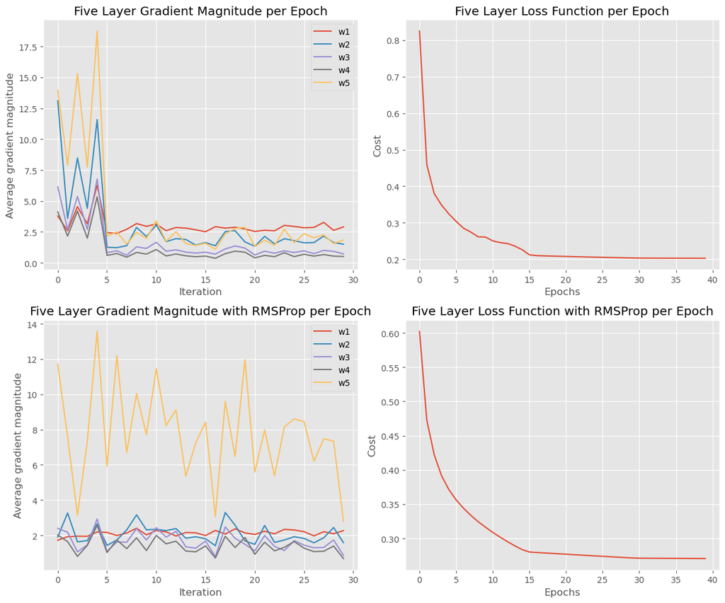

```
=================
Five-Layer Data Loss :
Resubstitution acc: 0.834510689056663
Validation acc: 0.8295191565955259
=================
Five-Layer Data Loss with RMSProp :
Resubstitution acc: 0.7613479711149047
Validation acc: 0.7568355189851719
```

```python
plt.subplots(figsize=(12, 10))

plt.subplot(2,2,1)
plt.plot(np.abs(nn_5.grad_w1_[10:]), label='w1')
plt.plot(np.abs(nn_5.grad_w2_[10:]), label='w2')
plt.plot(np.abs(nn_5.grad_w3_[10:]), label='w3')
plt.plot(np.abs(nn_5.grad_w4_[10:]), label='w4')
plt.plot(np.abs(nn_5.grad_w5_[10:]), label='w5')
plt.legend()
plt.title('Five Layer Gradient Magnitude per Epoch')
plt.ylabel('Average gradient magnitude')
plt.xlabel('Iteration')

plt.subplot(2,2,2)
plt.plot(range(len(nn_5.cost_)), nn_5.cost_)
plt.ylabel('Cost')
plt.xlabel('Epochs')
plt.title('Five Layer Loss Function per Epoch')
plt.tight_layout()

plt.subplot(2,2,3)
plt.plot(np.abs(nn_rms.grad_w1_[10:]), label='w1')
plt.plot(np.abs(nn_rms.grad_w2_[10:]), label='w2')
plt.plot(np.abs(nn_rms.grad_w3_[10:]), label='w3')
plt.plot(np.abs(nn_rms.grad_w4_[10:]), label='w4')
plt.plot(np.abs(nn_rms.grad_w5_[10:]), label='w5')
plt.legend()
plt.title('Five Layer Gradient Magnitude with RMSProp per Epoch')
plt.ylabel('Average gradient magnitude')
plt.xlabel('Iteration')

plt.subplot(2,2,4)
plt.plot(range(len(nn_rms.cost_)), nn_rms.cost_)
plt.ylabel('Cost')
plt.xlabel('Epochs')
plt.title('Five Layer Loss Function with RMSProp per Epoch')
plt.tight_layout()


plt.show()

print_result(nn_5,X_train_norm_OH,y_train_norm_OH,X_test_norm_OH,y_test_norm_OH,title="Five-Layer Data Loss",color="red")
print_result(nn_rms,X_train_norm_OH,y_train_norm_OH,X_test_norm_OH,y_test_norm_OH,title="Five-Layer Data Loss with RMSProp",color="red")
```

### Comparing Five Layer Performance Against Five Layer with Adaptive Learning RMSProp

I chose RMSProp for my adaptive learning technique. RMPSProp is a version of adaptive learning presented in-class and is a variation of the gradient descent algorithm. RMSProp stands for Root Mean Square Propogation and is very similar in its implementation to Adaptive Gradient. It introduces terms G and V, where G is the magnitude of the gradients squared and V is G times 1 minus a value, Gamma, plus Gamma times the previous V. Rho is then equal to the inverse root of V + epsilon times the gradient.

Comparing the performance of my five layer models I can see that RMSProp actually appears to have made the performance slightly worse. The gradient magnitudes in my normal 5-layer model largely remain close to one another and throught he first 5 epochs are nearly identical except in translation. The cost function eventually bottoms out after 40 epochs at around 0.2.

The version of my 5-layer model with RMSProp introduces greater variation in my w5 gradient values, though overall the values are lower than the standard 5-layer model. However the cost function does not converge as low as the standard version, above 0.2.

Comparing the accuracies, again RMSProp appears to have slightly negatively affected the accuracies with resubstition and validation roughly 7 percentage points lower, each.

## Adding support for ADAM

```python
# Source: Modified from in-class lecture for RMS Prop
class TLP_AdaM(TLPMiniBatch_5):
    def fit(self, X, y, print_progress=False, XY_test=None):
        """ Learn weights from training data. With mini-batch"""
        X_data, y_data = X.copy(), y.copy()
        Y_enc = self._encode_labels(y)

        # init weights and setup matrices
        self.n_features_ = X_data.shape[1]
        self.n_output_ = Y_enc.shape[0]
        self.W1, self.W2, self.W3, self.W4, self.W5, self.b1, self.b2, self.b3, self.b4, self.b5 = self._initialize_weights()

        # Establish gradient magnitude tracking arrays
        self.grad_w1_ = np.zeros(self.epochs)
        self.grad_w2_ = np.zeros(self.epochs)
        self.grad_w3_ = np.zeros(self.epochs)
        self.grad_w4_ = np.zeros(self.epochs)
        self.grad_w5_ = np.zeros(self.epochs)

        # Establish Hyperparemeters
        B1 = 0.9
        B2 = 0.999
        eta = 0.001
        eps = 10e-8
        k = 0

        # Adding initial Accumulated Gradient
        M1_prev = np.zeros(self.W1.shape)
        M2_prev = np.zeros(self.W2.shape)
        M3_prev = np.zeros(self.W3.shape)
        M4_prev = np.zeros(self.W4.shape)
        M5_prev = np.zeros(self.W5.shape)

        # Adding adaptive V for entire gradient
        V1_prev = np.zeros(self.W1.shape)
        V2_prev = np.zeros(self.W2.shape)
        V3_prev = np.zeros(self.W3.shape)
        V4_prev = np.zeros(self.W4.shape)
        V5_prev = np.zeros(self.W5.shape)

        # start momentum at zero for previous updates
        W1_prev = np.zeros(self.W1.shape)
        W2_prev = np.zeros(self.W2.shape)
        W3_prev = np.zeros(self.W3.shape)
        W4_prev = np.zeros(self.W4.shape)
        W5_prev = np.zeros(self.W5.shape)

        k = k + 1


        self.cost_ = []
        self.score_ = []
        # get starting acc
        self.score_.append(accuracy_score(y_data,self.predict(X_data)))
        # keep track of validation, if given
        if XY_test is not None:
            X_test = XY_test[0].copy()
            y_test = XY_test[1].copy()
            self.val_score_ = []
            self.val_score_.append(accuracy_score(y_test,self.predict(X_test)))
            self.val_cost_ = []

        for i in range(self.epochs):

            # adaptive learning rate
            # decrease at certain epochs
            eta = self.eta * self.decrease_const**(np.floor(i/self.decrease_iter))

            if print_progress>0 and (i+1)%print_progress==0:
                sys.stderr.write('\rEpoch: %d/%d' % (i+1, self.epochs))
                sys.stderr.flush()

            if self.shuffle:
                idx_shuffle = np.random.permutation(y_data.shape[0])
                X_data, Y_enc, y_data = X_data[idx_shuffle], Y_enc[:, idx_shuffle], y_data[idx_shuffle]

            mini = np.array_split(range(y_data.shape[0]), self.minibatches)
            mini_cost = []

            for idx in mini:
                # feedforward
                A1, Z1, A2, Z2, A3, Z3, A4, Z4, A5, Z5, A6 = self._feedforward(
                                                                               X_data[idx],
                                                                               self.W1,
                                                                               self.W2,
                                                                               self.W3,
                                                                               self.W4,
                                                                               self.W5,
                                                                               self.b1,
                                                                               self.b2,
                                                                               self.b3,
                                                                               self.b4,
                                                                               self.b5
                                                                               )

                cost = self._cost(A6,Y_enc[:, idx],self.W1,self.W2,self.W3,self.W4,self.W5)
                mini_cost.append(cost) # this appends cost of mini-batch only

                # compute gradient via backpropagation
                gradW1, gradW2, gradW3, gradW4, gradW5, gradb1, gradb2, gradb3, gradb4, gradb5 = self._get_gradient(
                                                                                    A1=A1,
                                                                                    A2=A2,
                                                                                    A3=A3,
                                                                                    A4=A4,
                                                                                    A5=A5,
                                                                                    A6=A6,
                                                                                    Z1=Z1,
                                                                                    Z2=Z2,
                                                                                    Z3=Z3,
                                                                                    Z4=Z4,
                                                                                    Z5=Z5,
                                                                                    Y_enc=Y_enc[:, idx],
                                                                                    W1=self.W1,
                                                                                    W2=self.W2,
                                                                                    W3=self.W3,
                                                                                    W4=self.W4,
                                                                                    W5=self.W5
                                                                                    )

                # Implementing V for AdaM
                V1 = B2*V1_prev + (1-B2)*(gradW1*gradW1)
                V2 = B2*V2_prev + (1-B2)*(gradW2*gradW2)
                V3 = B2*V3_prev + (1-B2)*(gradW3*gradW3)
                V4 = B2*V4_prev + (1-B2)*(gradW4*gradW4)
                V5 = B2*V5_prev + (1-B2)*(gradW5*gradW5)

                # Implementing M for RMS Prop
                M1 = B1*M1_prev + (1-B1)*gradW1
                M2 = B1*M2_prev + (1-B1)*gradW2
                M3 = B1*M3_prev + (1-B1)*gradW3
                M4 = B1*M4_prev + (1-B1)*gradW4
                M5 = B1*M5_prev + (1-B1)*gradW5

                # AdaM Implementation
                M1_hat = M1/np.sqrt(1-(B1**k))
                M2_hat = M2/np.sqrt(1-(B1**k))
                M3_hat = M3/np.sqrt(1-(B1**k))
                M4_hat = M4/np.sqrt(1-(B1**k))
                M5_hat = M5/np.sqrt(1-(B1**k))

                V1_hat = V1/np.sqrt(1-(B2**k))
                V2_hat = V2/np.sqrt(1-(B2**k))
                V3_hat = V3/np.sqrt(1-(B2**k))
                V4_hat = V4/np.sqrt(1-(B2**k))
                V5_hat = V5/np.sqrt(1-(B2**k))


                # add support for tracking the magnitude of the gradients
                def grad_w1_(gradW1):
                    self.grad_w1_[i] = np.mean(np.abs(gradW1))

                    return grad_w1_


                def grad_w2_(gradW2):
                    self.grad_w2_[i] = np.mean(np.abs(gradW2))

                    return grad_w2_


                def grad_w3_(gradW3):
                    self.grad_w3_[i] = np.mean(np.abs(gradW3))

                    return grad_w3_


                def grad_w4_(gradW4):
                    self.grad_w4_[i] = np.mean(np.abs(gradW4))

                    return grad_w4_


                def grad_w5_(gradW5):
                    self.grad_w5_[i] = np.mean(np.abs(gradW5))

                    return grad_w5_


                # Track the magnitude of the gradient
                grad_w1_(gradW1)
                grad_w2_(gradW2)
                grad_w3_(gradW3)
                grad_w4_(gradW4)
                grad_w5_(gradW5)

                # Update the weights
                self.W1 -= W1_prev - eta*M1_hat/np.sqrt(V1_hat + eps) # update with AdaM
                self.W2 -= W2_prev - eta*M2_hat/np.sqrt(V2_hat + eps) # update with AdaM
                self.W3 -= W3_prev - eta*M3_hat/np.sqrt(V3_hat + eps) # update with AdaM
                self.W4 -= W4_prev - eta*M4_hat/np.sqrt(V4_hat + eps) # update with AdaM
                self.W5 -= W5_prev - eta*M5_hat/np.sqrt(V5_hat + eps) # update with AdaM

                # no need for momentum in bias
                # these values need to change abruptly and
                # do not influence sensitivity backward
                self.b1 -= eta * gradb1
                self.b2 -= eta * gradb2
                self.b3 -= eta * gradb3
                self.b4 -= eta * gradb4
                self.b5 -= eta * gradb5

                # update previous parameters
                W1_prev, W2_prev, W3_prev, W4_prev, W5_prev = self.W1, self.W2, self.W3, self.W4, self.W5
                M1_prev, M2_prev, M3_prev, M4_prev, M5_prev = M1, M2, M3, M4, M5

            self.cost_.append(np.mean(mini_cost))
            self.score_.append(accuracy_score(y_data,self.predict(X_data)))

            # update if a validation set was provided
            if XY_test is not None:
                yhat = self.predict(X_test)
                self.val_score_.append(accuracy_score(y_test,yhat))

        return self
```

```python
nn_AdaM = TLP_AdaM(**vals)

%time nn_AdaM.fit(X_train_norm_OH, y_train_norm_OH, print_progress=1, XY_test=(X_test_norm_OH, y_test_norm_OH))
yhat = nn_AdaM.predict(X_train_norm_OH)
```

```
Epoch: 40/40
```

```
CPU times: total: 2min 56s
Wall time: 1min 9s
```

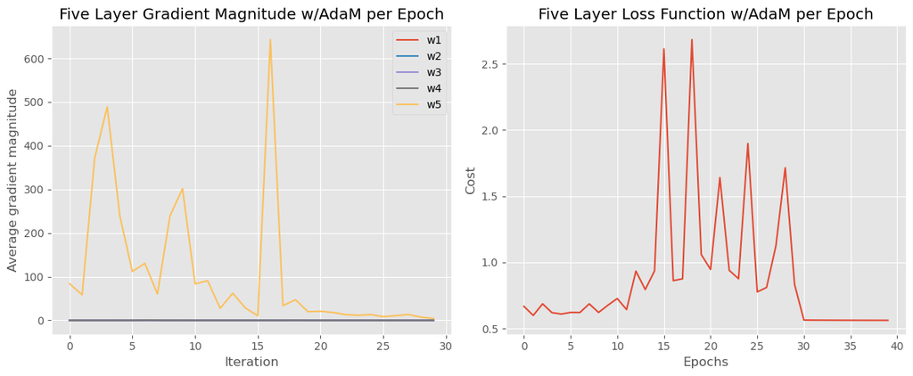

```
=================
Five-Layer Data Loss w/ AdaM :
Resubstitution acc: 0.26664428619386726
Validation acc: 0.2660209708294049
```

```python
plt.subplots(figsize=(12, 5))

plt.subplot(1,2,1)
plt.plot(np.abs(nn_AdaM.grad_w1_[10:]), label='w1')
plt.plot(np.abs(nn_AdaM.grad_w2_[10:]), label='w2')
plt.plot(np.abs(nn_AdaM.grad_w3_[10:]), label='w3')
plt.plot(np.abs(nn_AdaM.grad_w4_[10:]), label='w4')
plt.plot(np.abs(nn_AdaM.grad_w5_[10:]), label='w5')
plt.legend()
plt.title('Five Layer Gradient Magnitude w/AdaM per Epoch')
plt.ylabel('Average gradient magnitude')
plt.xlabel('Iteration')

plt.subplot(1,2,2)
plt.plot(range(len(nn_AdaM.cost_)), nn_AdaM.cost_)
plt.ylabel('Cost')
plt.xlabel('Epochs')
plt.title('Five Layer Loss Function w/AdaM per Epoch')
plt.tight_layout()
plt.show()

plt.show()

print_result(nn_AdaM,X_train_norm_OH,y_train_norm_OH,X_test_norm_OH,y_test_norm_OH,title="Five-Layer Data Loss w/ AdaM",color="red")
```